# BA 64060 Final Exam

# Determine the new best value of k using the “elbow” chart

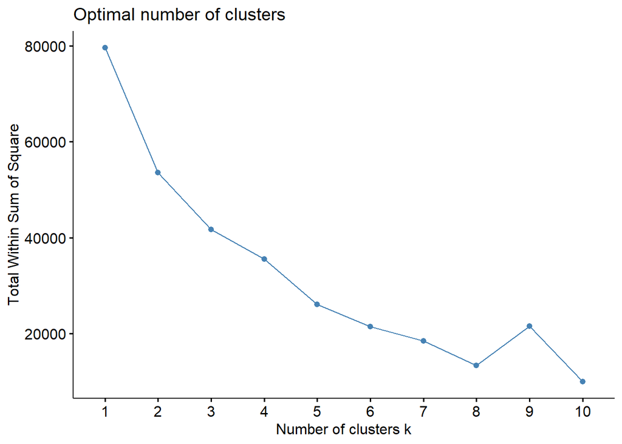

```r
fviz_nbclust(fuel.ds7, kmeans, method = "wss")
```

# The output above displays that around 5 or 6 is the ideal value for k (slope stops being as steep)

# Determine the best value for k using the Silhouette Method; compare to “elbow” chart results

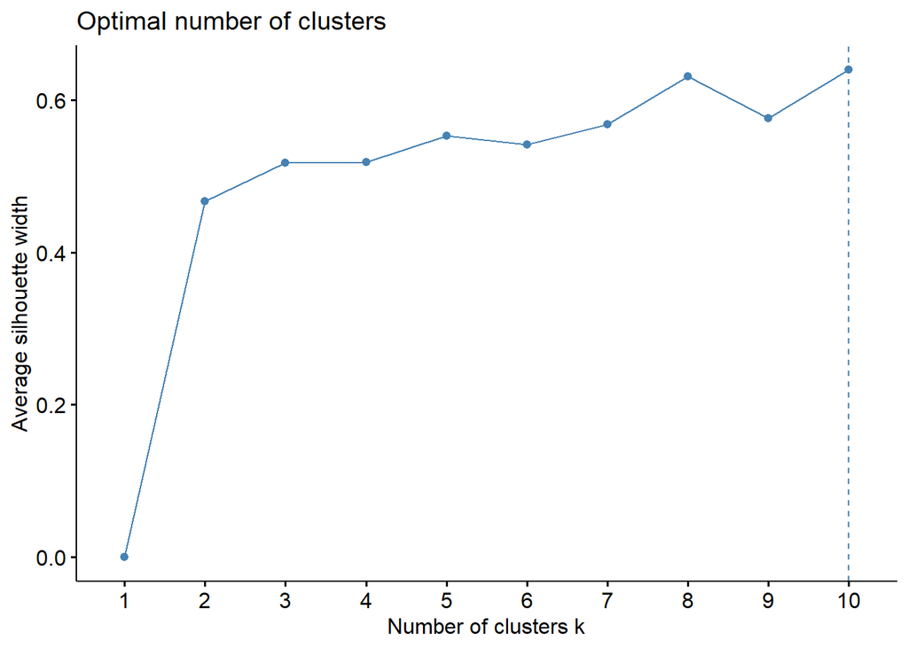

```r
fviz_nbclust(fuel.ds7, kmeans, method = "silhouette")
```

# The silhouette chart displays that 10 is the ideal value for k, which differs from the elbow chart.

# Run k-means using k = 5, number of restarts = 25

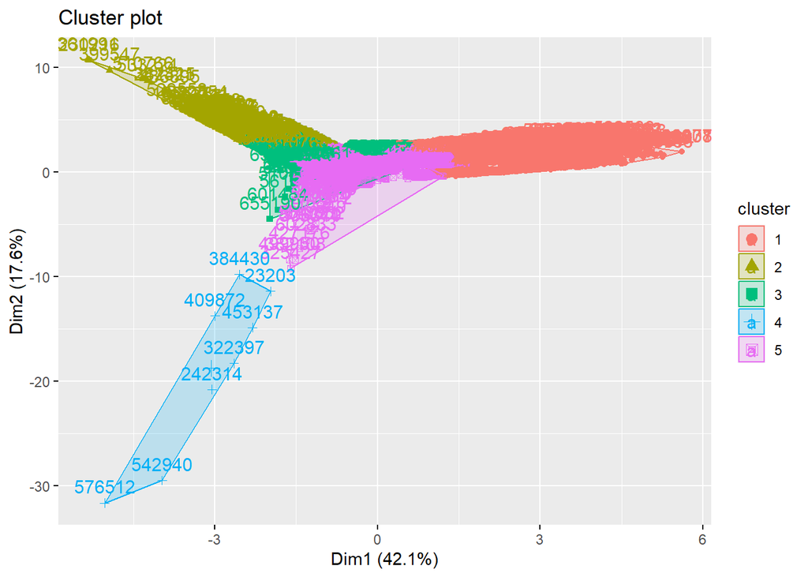

```r
set.seed(129)
fuel_k4 <- kmeans(fuel.ds7, centers = 5, nstart = 25)
fviz_cluster(fuel_k4, data = fuel.ds7)
```

```r
fuel_k4$cluster
```

[output not shown]

[output cut: 2399 more lines]

```r
fuel_k4$size
```

```
## [1] 3118  629 2946    8 6567
```

# After removing the 3 records with the maximum fuel cost in the sample, the clusters are more defined. Removing the 3 records affected the mean which would have affected the imputing of values as well.

# Out of curiosity, run k-means using k = 10, number of restarts = 25

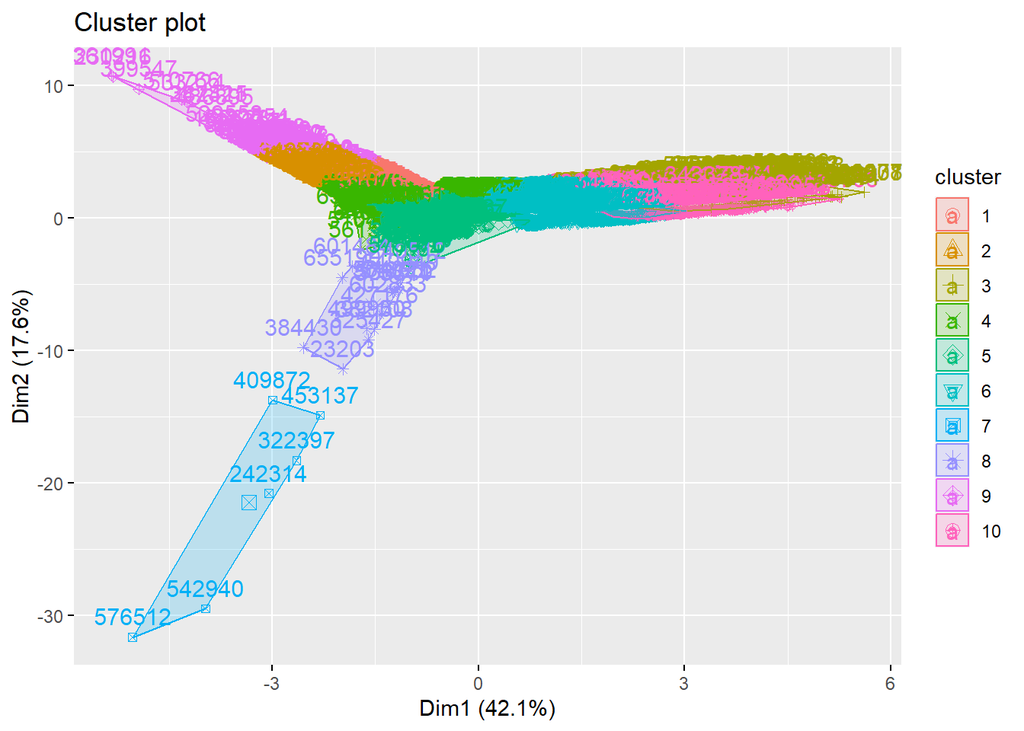

```r
set.seed(129)
fuel_k5 <- kmeans(fuel.ds7, centers = 10, nstart = 25)
fviz_cluster(fuel_k5, data = fuel.ds7)
```

```r
fuel_k5$cluster
```

[output not shown]

[output cut: 2399 more lines]

```r
fuel_k5$size
```

```
##  [1]  319  502  201 2840 4816 3011    6   15   90 1468
```

# Again, the output is still the same general shape as k = 5, but more clusters have been added. It looks like there’s significant overlap between clusters 10, 3, and 6. Adding more clusters in this scenario doesn’t appear to generate additional insight.

# For the final analysis, I am reverting back to k = 5:

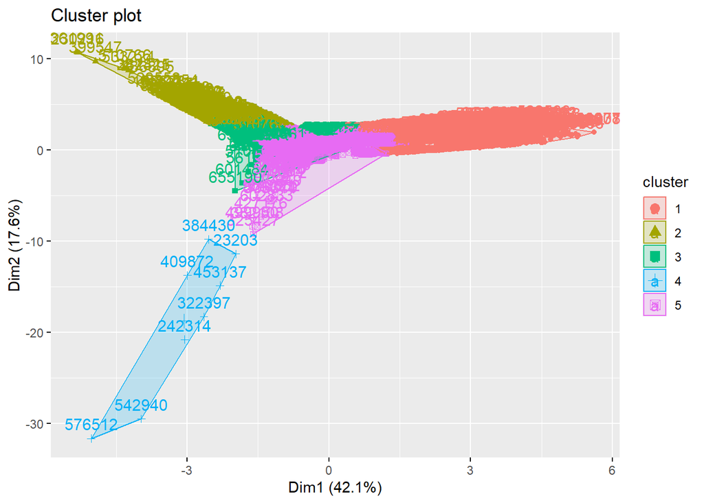

```r
set.seed(129)
fuel_k4 <- kmeans(fuel.ds7, centers = 5, nstart = 25)
fviz_cluster(fuel_k4, data = fuel.ds7)
```

```r
fuel_k4$cluster
```

[output not shown]

[output cut: 2399 more lines]

```r
fuel_k4$size
```

```
## [1] 3118  629 2946    8 6567
```

# Questions/topics I want to address during the analysis:

# 1.) What is the most costly fuel? Least costly?

# 2.) Confirm what fuels have the highest sulfer and ash content? Lowest of both?

# 3.) Describe the clusters produced.

# 4.) Recommendation on power generation in the US + what cluster(s) represent good examples of predominantly natural gas transactions at a reasonable price?

# Answers:

# 1.) Although natural gas can definitely have below average costs, it is disproportionately represented among the highest fuel costs. Coal is disproportionately represented among the lowest fuel costs.

# 2.) Coal burns the hottest with the highest amount of ash and sulfur. Natural gas has no ash or sulfur content, has the lowest heat content, and therefore burns the cleanest.

# 3.) Cluster descriptions:

# Cluster 1: The second largest cluster, representing 3118 records. This cluster is characterized by predominantly coal fuel type and high sulfur and ash content. Also represents below average fuel cost. Could be referred to as the low cost, “dirty” fuel cluster.

# Cluster 2: The second smallest cluster, with 629 records represented. This cluster is characterized by predominantly natural gas fuel type with very large amounts of fuel received and average to below average fuel cost. Large amounts of natural gas received is the defining characteristic of this cluster.

# Cluster 3: The medium-sized cluster representing 2946 records. This cluster is characterized by predominantly natural gas with average to above average amounts of fuel received and average to below average fuel costs. Most records in this cluster were spot purchases. This is the lower cost, average/above average fuel received, spot purchases of natural gas cluster.

# Cluster 4: The smallest cluster, representing 8 records. This cluster is characterized by natural gas with very minimal amounts of fuel received and very high fuel costs. All records in this cluster were spot purchases. This could be considered as the outlier cluster – unique occasions.

# Cluster 5: The largest cluster, representing 6567 records. This cluster is characterized by a blend of natural gas and coal fuel types, with no noticeable pattern to the amount of fuel received or fuel cost. Represents wide range of plant IDs and report dates. “Catch-all” cluster representing diverse set of records.

# 4.) Although it can come at a higher cost, natural gas is the cleanest form of fossil fuel available today. There may be scenarios where coal and petroleum are still appropriate, but power plants should generally trend in favor of natural gas. The power plants in clusters 2 and 3 should serve as model examples for energy usage in the US given their high reliance on natural gas at a reasonable price. Depending on the desired contract type (contract vs. spot), one could focus more on either cluster 2 (more contract) or cluster 3 (mostly spot).